# notebook_model_

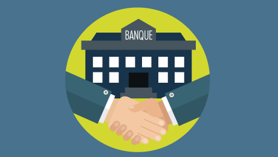

Contributeurs : *Amadou BAH, Frederic AKADJE*

## Introduction

`African scoring challenge` est une compétition type kaggle organisé par Zindi [Visitez Zindi Africa ici](https://zindi.africa/).  
**Objectif :** Construire un modèle machine learning généralisable afin de prédire le remboursement ou non d'un prêt bancaire. [lien compétion](https://zindi.africa/competitions/african-credit-scoring-challenge)

**Contexte :**  
Un dataset est mis à dispositions, il regroupe les demandes de prêt de différents acteurs économique du Kenya ainsi que leur issue (remboursé ou non). L'évaluation sera réalisée sur les demandes de prêts des population du Kenya et du Ghana.

La demarche proposée ici s'inspire grandement de l'approche de PhD. Oluwatobi Afolabi, 3è au classement du challenge.  
Son notebook est disponible ici : https://www.kaggle.com/code/tobby18/african-credit-scoring-challenge-zindi-final#Model-Development

#### Points clés du notebook :

Analyse exploratoire

Data processing

Feature Engineering

Construction du modèle

Construction du score de crédit

Recommandation

```python
# === Librairies ===

import warnings
warnings.filterwarnings('ignore')

import pandas as pd
import numpy as np

# Visualisation
import matplotlib.pyplot as plt
import seaborn as sns

# Machine Learning
from sklearn.preprocessing import LabelEncoder
from sklearn.model_selection import StratifiedKFold
from sklearn.metrics import classification_report
from sklearn.metrics import f1_score
from scipy.stats import mode

# Advanced ML Models
from imblearn.over_sampling import BorderlineSMOTE
import xgboost as xgb
from lightgbm import LGBMClassifier
from catboost import CatBoostClassifier
from sklearn.tree import DecisionTreeClassifier
```

## Apperçu du jeu de données

### Variables du jeu de données

| Nom de la variable | Description |
| --- | --- |
| `ID` | Identifiant unique pour chaque entrée du jeu de données. |
| `customer_id` | Identifiant unique pour chaque client dans le jeu de données. |
| `country_id` | Identifiant ou code représentant le pays du client ou du prêt. |
| `tbl_loan_id` | Identifiant unique pour chaque prêt associé au client. |
| `Total_Amount` | Montant total du prêt initialement versé au client. |
| `Total_Amount_to_Repay` | Montant total à rembourser par le client (capital + intérêts + frais). |
| `loan_type` | Catégorie ou type de prêt. |
| `disbursement_date` | Date à laquelle le montant du prêt a été versé au client. |
| `duration` | Durée du prêt, généralement exprimée en jours. |
| `lender_id` | Identifiant unique pour le prêteur ou l'institution ayant accordé le prêt. |
| `New_versus_Repeat` | Indique si le prêt est le premier ("New") ou non ("Repeat"). |
| `Amount_Funded_By_Lender` | Portion du prêt financée directement par le prêteur. |
| `Lender_portion_Funded` | Pourcentage du montant total du prêt financé par le prêteur. |
| `due_date` | Date limite à laquelle le remboursement du prêt est dû. |
| `Lender_portion_to_be_repaid` | Portion du prêt impayé qui doit être remboursée au prêteur. |
| `target` | Variable cible : 0 = prêt remboursé, 1 = prêt non remboursé (défaut). |

```python
# Chargement des jeux de données train et test
train = pd.read_csv('data/Train.csv')
test = pd.read_csv('data/Test.csv')
# Affichage des jeux de données
display("Train", train.head(3), train.shape, "Test", test.head(5), test.shape)
```

```
'Train'
```

|  | ID | customer_id | country_id | tbl_loan_id | lender_id | loan_type | Total_Amount | Total_Amount_to_Repay | disbursement_date | due_date | duration | New_versus_Repeat | Amount_Funded_By_Lender | Lender_portion_Funded | Lender_portion_to_be_repaid | target |
| --- | --- | --- | --- | --- | --- | --- | --- | --- | --- | --- | --- | --- | --- | --- | --- | --- |
| 0 | ID_266671248032267278 | 266671 | Kenya | 248032 | 267278 | Type_1 | 8448.0 | 8448.0 | 2022-08-30 | 2022-09-06 | 7 | Repeat Loan | 120.85 | 0.014305 | 121.0 | 0 |
| 1 | ID_248919228515267278 | 248919 | Kenya | 228515 | 267278 | Type_1 | 25895.0 | 25979.0 | 2022-07-30 | 2022-08-06 | 7 | Repeat Loan | 7768.50 | 0.300000 | 7794.0 | 0 |
| 2 | ID_308486370501251804 | 308486 | Kenya | 370501 | 251804 | Type_7 | 6900.0 | 7142.0 | 2024-09-06 | 2024-09-13 | 7 | Repeat Loan | 1380.00 | 0.200000 | 1428.0 | 0 |

```
(68654, 16)
```

```
'Test'
```

|  | ID | customer_id | country_id | tbl_loan_id | lender_id | loan_type | Total_Amount | Total_Amount_to_Repay | disbursement_date | due_date | duration | New_versus_Repeat | Amount_Funded_By_Lender | Lender_portion_Funded | Lender_portion_to_be_repaid |
| --- | --- | --- | --- | --- | --- | --- | --- | --- | --- | --- | --- | --- | --- | --- | --- |
| 0 | ID_269404226088267278 | 269404 | Kenya | 226088 | 267278 | Type_1 | 1919.0 | 1989.0 | 2022-07-27 | 2022-08-03 | 7 | Repeat Loan | 575.7 | 0.300000 | 597.0 |
| 1 | ID_255356300042267278 | 255356 | Kenya | 300042 | 267278 | Type_1 | 2138.0 | 2153.0 | 2022-11-16 | 2022-11-23 | 7 | Repeat Loan | 0.0 | 0.000000 | 0.0 |
| 2 | ID_257026243764267278 | 257026 | Kenya | 243764 | 267278 | Type_1 | 8254.0 | 8304.0 | 2022-08-24 | 2022-08-31 | 7 | Repeat Loan | 207.0 | 0.025079 | 208.0 |
| 3 | ID_264617299409267278 | 264617 | Kenya | 299409 | 267278 | Type_1 | 3379.0 | 3379.0 | 2022-11-15 | 2022-11-22 | 7 | Repeat Loan | 1013.7 | 0.300000 | 1014.0 |
| 4 | ID_247613296713267278 | 247613 | Kenya | 296713 | 267278 | Type_1 | 120.0 | 120.0 | 2022-11-10 | 2022-11-17 | 7 | Repeat Loan | 36.0 | 0.300000 | 36.0 |

```
(18594, 15)
```

```python
# Types de données et potentielles valeurs manquantes
train.info()
```

```
<class 'pandas.core.frame.DataFrame'>
RangeIndex: 68654 entries, 0 to 68653
Data columns (total 16 columns):
 #   Column                       Non-Null Count  Dtype
---  ------                       --------------  -----
 0   ID                           68654 non-null  object
 1   customer_id                  68654 non-null  int64
 2   country_id                   68654 non-null  object
 3   tbl_loan_id                  68654 non-null  int64
 4   lender_id                    68654 non-null  int64
 5   loan_type                    68654 non-null  object
 6   Total_Amount                 68654 non-null  float64
 7   Total_Amount_to_Repay        68654 non-null  float64
 8   disbursement_date            68654 non-null  object
 9   due_date                     68654 non-null  object
 10  duration                     68654 non-null  int64
 11  New_versus_Repeat            68654 non-null  object
 12  Amount_Funded_By_Lender      68654 non-null  float64
 13  Lender_portion_Funded        68654 non-null  float64
 14  Lender_portion_to_be_repaid  68654 non-null  float64
 15  target                       68654 non-null  int64
dtypes: float64(5), int64(5), object(6)
memory usage: 8.4+ MB
```

```python
# Valeurs manquantes
print(f"Il y a {train.isna().sum().sum()} valeur manquantes.")
```

```
Il y a 0 valeur manquantes.
```

# Analyse exploratoire

```python
# Copie des datasets pour éviter les modifications en place
train_copy = train.copy()
test_copy = test.copy()

# Ajout d'une colonne 'dataset' pour différencier train et test
train_copy['dataset'] = 'Train'
test_copy['dataset'] = 'Test'
```

**Répartition des prêts par pays dans les échantillions train test**

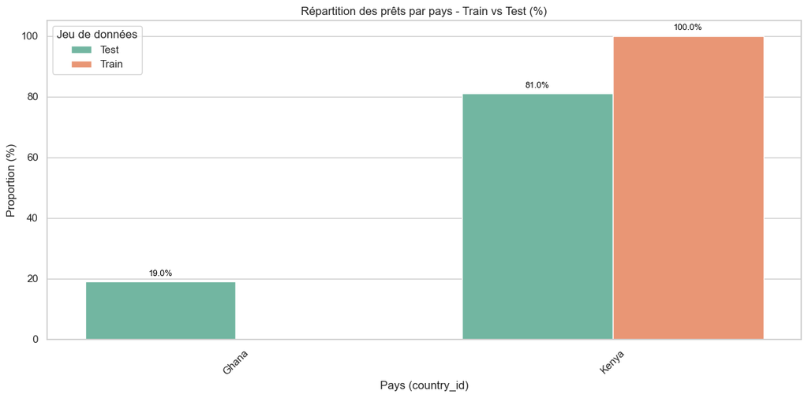

```python
# Concaténation des deux datasets sur la variable d'intérêt
combined = pd.concat([train_copy[['country_id', 'dataset']], test_copy[['country_id', 'dataset']]])

# Calcul des proportions (%)
counts = combined.groupby(['country_id', 'dataset']).size().reset_index(name='count')
total_per_dataset = counts.groupby('dataset')['count'].transform('sum')
counts['percentage'] = (counts['count'] / total_per_dataset * 100).round(1)

# Barplot groupé
plt.figure(figsize=(12, 6))
bar = sns.barplot(
    data=counts,
    x='country_id',
    y='percentage',
    hue='dataset',
    palette='Set2'
)

# Ajout des annotations en pourcentage sur les barres
for p in bar.patches:
    height = p.get_height()
    if height > 0:
        bar.annotate(f"{height:.1f}%",
                     (p.get_x() + p.get_width() / 2., height),
                     ha='center', va='bottom', fontsize=9, color='black',
                     xytext=(0, 4), textcoords='offset points')

# Titres et mise en forme
plt.title("Répartition des prêts par pays - Train vs Test (%)")
plt.xlabel("Pays (country_id)")
plt.ylabel("Proportion (%)")
plt.xticks(rotation=45)
plt.legend(title="Jeu de données")
plt.tight_layout()
plt.show()
```

> Une forte disproportion géographique entre les jeux de données d'entraînement et de test apparaît. Le Kenya domine largement le jeu d'entraînement, tandis que le Ghana ni figure pas. Ce biais géographique doit être pris en compte pour éviter des performances décevantes du modèle sur des données provenant d'autres pays.

> Cette différence peut poser des problèmes de généralisation si le modèle est entraîné uniquement sur des données provenant du Kenya, car il pourrait ne pas bien performer sur des données provenant d'autres pays comme le Ghana.

**Occurrences des étiquettes (target) dans le train**

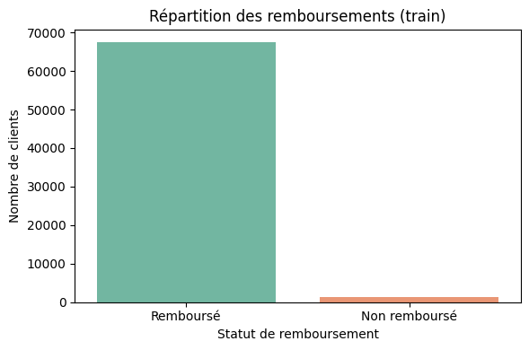

```python
plt.figure(figsize=(6, 4))
sns.countplot(data=train, x='target', palette='Set2')
plt.xticks([0, 1], ['Remboursé', 'Non remboursé'])
plt.title("Répartition des remboursements (train)")
plt.xlabel("Statut de remboursement")
plt.ylabel("Nombre de clients")
plt.tight_layout()
plt.show()
```

> Une distribution fortement déséquilibrée apparaît au niveau des étiquettes dans le jeu d'entraînement, avec 98 % de prêts remboursés (classe 0) et seulement 2 % de défauts de paiement (classe 1). Cela traduit une sous-représentation marquée des défauts de paiement (la classe minoritaire).

**Répartition des types de prêts dans train vs test**

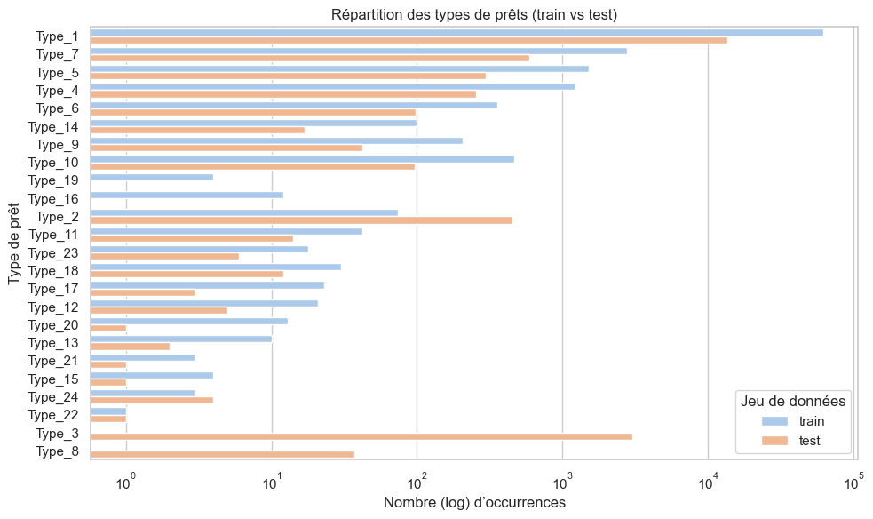

```python
plt.figure(figsize=(10, 6))
loan_type_counts = pd.concat([train_copy[['loan_type', 'set']], test_copy[['loan_type', 'set']]])
sns.countplot(data=loan_type_counts, y='loan_type', hue='set', palette='pastel')
plt.title("Répartition des types de prêts (train vs test)")
plt.xlabel("Nombre (log) d’occurrences")
plt.ylabel("Type de prêt")
plt.legend(title="Jeu de données")
plt.xscale('log')
plt.tight_layout()
plt.show()
```

> Par ailleurs, La distribution globale des types de prêts semble incohérente entre train et test. Cela se perçoit par la présence de certains prêteurs présent dans les données test, pourtant abscents dans les données d'entraînements.

**Occurrences des types de prêteurs (lender_id) dans train vs test**

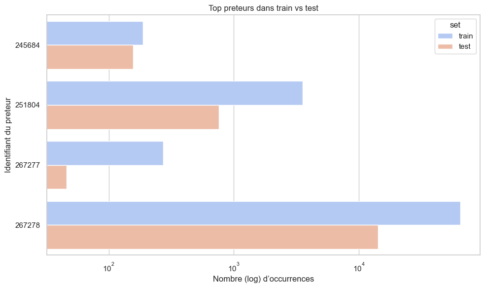

```python
top_lenders = train_copy['lender_id'].value_counts().nlargest(10).index
filtered_train = train_copy[train_copy['lender_id'].isin(top_lenders)]
filtered_test = test_copy[test_copy['lender_id'].isin(top_lenders)]

lender_counts = pd.concat([filtered_train[['lender_id', 'set']], filtered_test[['lender_id', 'set']]])

plt.figure(figsize=(10, 6))
sns.countplot(data=lender_counts, y='lender_id', hue='set', palette='coolwarm')
plt.title("Top preteurs dans train vs test")
plt.xlabel("Nombre (log) d’occurrences")
plt.ylabel("Identifiant du preteur")
plt.xscale('log')
plt.tight_layout()
plt.show()
```

> De la comparaison des occurrences des identifiants de prêteurs (lender_id) entre les jeux de données d'entraînement (train) et de test il ressort que :
- Lender_267278 est le prêteur le plus fréquent dans le jeu d'entraînement, avec un nombre d'occurrences très élevé. Il démeure également le prêteur le plus sollicité dans le jeu de test, mais à un niveau beaucoup plus faible par rapport au train
- Les autres prêteurs (Lender_251804, Lender_245684,...) ont des occurrences très faibles ou quasi-nulles, présumant un rôle minime de ces acteurs.
- La distribution globale des prêteurs semble cohérente entre train et test, bien que l'écart soit marqué pour le prêteur principal (Lender_267278).

**Distribution du montant total du prêt (Total_Amount)**

[figure not shown]

```python
# Ajouter target aux donnees train pour la coloration
train_with_label = train.copy()
train_with_label['dataset'] = 'Train'
test_with_label = test.copy()
test_with_label['dataset'] = 'Test'

combined_amount = pd.concat([
    train_with_label[['Total_Amount', 'dataset', 'target']],
    test_with_label[['Total_Amount', 'dataset']]
])

# Convertir target en label lisible
combined_amount['target_label'] = combined_amount['target'].map({0: 'Rembourse', 1: 'Non rembourse'})

plt.figure(figsize=(8,6))
sns.boxplot(data=combined_amount, x='dataset', y='Total_Amount', hue='target_label', palette='Set2')
sns.stripplot(data=combined_amount, x='dataset', y='Total_Amount', jitter=True, alpha=0.6, color='gray', size=3)

plt.title("Distribution du montant total du pret (Total_Amount) - Train vs Test")
plt.xlabel("Jeu de donnees")
plt.ylabel("Montant total du pret")
plt.legend(title="Statut du pret (Train uniquement)")
plt.yscale('log')  # Pour mieux visualiser les ecarts
plt.tight_layout()
plt.show()
```

> La distribution des montants totaux reste assez similaire des échantillons test et train. Les valeurs sont concentrées autour de quelques ordres de grandeur, avec une majorité de prêts ayant des montants relativement faibles. Il existe quelques outliers à très hauts montants, mais ils sont rares.

> Cependant, une différence notable émerge, si l'on jette un regard au niveau de la répartition des montants selon les modalités 'remboursé' et 'non-rembourser'. Une dominance prononcée des défauts de paiements apparaît ainsi pour les montants plus importants.

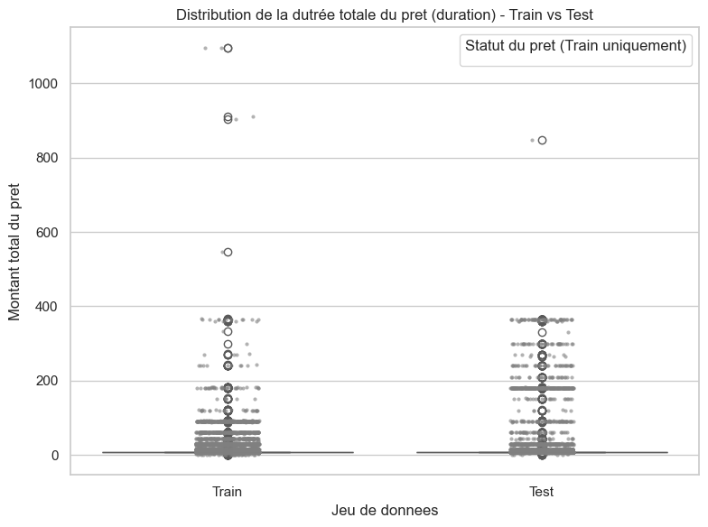

```python
combined_duration = pd.concat([
    train_with_label[['duration', 'dataset', 'target']],
    test_with_label[['duration', 'dataset']]
])
combined_duration['target_label'] = combined_duration['target'].map({0: 'Rembourse', 1: 'Non rembourse'})

plt.figure(figsize=(8,6))
sns.boxplot(data=combined_duration, x='dataset', y='duration', palette='Set2')
sns.stripplot(data=combined_duration, x='dataset', y='duration', jitter=True, alpha=0.6, color='gray', size=3)

plt.title("Distribution de la dutrée totale du pret (duration) - Train vs Test")
plt.xlabel("Jeu de donnees")
plt.ylabel("Montant total du pret")
plt.legend(title="Statut du pret (Train uniquement)")
plt.tight_layout()
plt.show()
```

**Croisement Total_Amount vs Total_Amount_to_Repay (train vs test)**

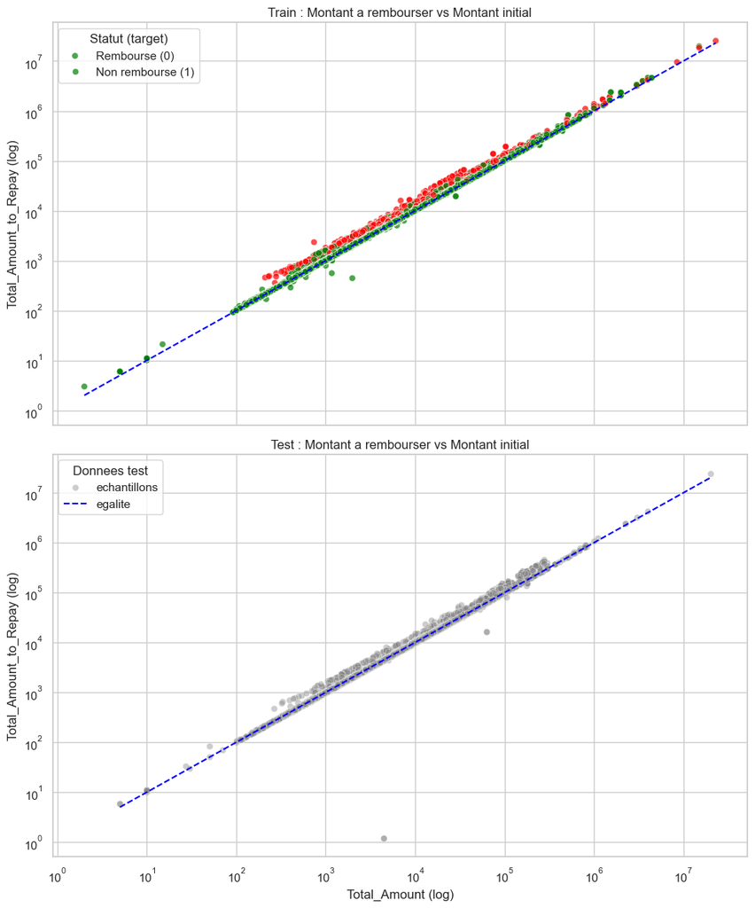

```python
import matplotlib.pyplot as plt
import seaborn as sns

# Setup style
sns.set(style='whitegrid')

# Figure avec 2 lignes (vertical)
fig, axes = plt.subplots(2, 1, figsize=(10, 12), sharex=True, sharey=True)

# Graphe 1 : Donnees TRAIN avec target
sns.scatterplot(
    data=train,
    x='Total_Amount',
    y='Total_Amount_to_Repay',
    hue='target',
    palette={0: 'green', 1: 'red'},
    alpha=0.7,
    ax=axes[0]
)
axes[0].plot(
    [train['Total_Amount'].min(), train['Total_Amount'].max()],
    [train['Total_Amount'].min(), train['Total_Amount'].max()],
    color='blue', linestyle='--', label='egalite'
)
axes[0].set_title("Train : Montant a rembourser vs Montant initial")
axes[0].set_xlabel("")
axes[0].set_ylabel("Total_Amount_to_Repay (log)")
axes[0].set_xscale('log')
axes[0].set_yscale('log')
axes[0].legend(title='Statut (target)', labels=['Rembourse (0)', 'Non rembourse (1)'])

# Graphe 2 : Donnees TEST sans target
sns.scatterplot(
    data=test,
    x='Total_Amount',
    y='Total_Amount_to_Repay',
    color='gray',
    alpha=0.4,
    ax=axes[1]
)
axes[1].plot(
    [test['Total_Amount'].min(), test['Total_Amount'].max()],
    [test['Total_Amount'].min(), test['Total_Amount'].max()],
    color='blue', linestyle='--', label='egalite'
)
axes[1].set_title("Test : Montant a rembourser vs Montant initial")
axes[1].set_xlabel("Total_Amount (log)")
axes[1].set_ylabel("Total_Amount_to_Repay (log)")
axes[1].set_xscale('log')
axes[1].set_yscale('log')
axes[1].legend(title='Donnees test', labels=['echantillons', 'egalite'])

plt.tight_layout()
plt.show()
```

> La plupart des points suivent une tendance ascendante proche de la ligne d'égalité (y = x), indiquant que le montant à rembourser est généralement proche du montant initial. Les points rouges (non remboursés) se situent au dessus de la ligne d'égalité, suggérant des montants à rembouser plus importants. A contratio, les points verts (remboursés) sont généralement dispersés en dessous de la ligne d'égalité avec des concentrations autour de cette ligne. Cette dispersion initiale se généralise au niveau de l'échantillon test.

**Nombre de crédits pris vs remboursés par utilisateur**

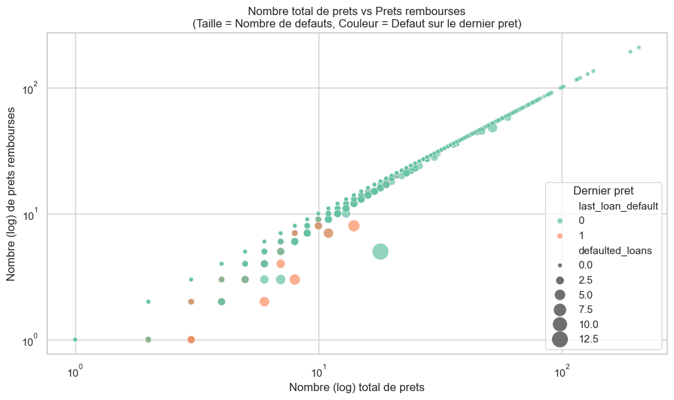

```python
# Compter le nombre de prets par client
loan_count_train = train.groupby('customer_id').size().reset_index(name='total_loans')

# Compter le nombre de prets rembourses par client
repaid_loans = train[train['target'] == 0].groupby('customer_id').size().reset_index(name='repaid_loans')

# Fusionner les deux
loan_stats = pd.merge(loan_count_train, repaid_loans, on='customer_id', how='left')
loan_stats['defaulted_loans'] = loan_stats['total_loans'] - loan_stats['repaid_loans'].fillna(0)

# Ajouter une colonne pour identifier si le dernier pret est en defaut
last_loan_status = train.groupby('customer_id')['target'].last().reset_index()
last_loan_status.columns = ['customer_id', 'last_loan_default']

loan_stats = pd.merge(loan_stats, last_loan_status, on='customer_id', how='inner')

plt.figure(figsize=(10,6))
scatter = sns.scatterplot(
    data=loan_stats,
    x='total_loans',
    y='repaid_loans',
    size='defaulted_loans',
    sizes=(20, 300),
    hue='last_loan_default',
    palette='Set2',
    alpha=0.7,
    legend='brief'
)

plt.title("Nombre total de prets vs Prets rembourses\n(Taille = Nombre de defauts, Couleur = Defaut sur le dernier pret)")
plt.xlabel("Nombre (log) total de prets")
plt.xscale('log')
plt.yscale('log')
plt.ylabel("Nombre (log) de prets rembourses")
plt.grid(True)
plt.legend(title="Dernier pret", loc='lower right')
plt.tight_layout()
plt.show()
```

- Les points verts (dernier prêt remboursé) majoritairement concentrés sur ou près de la diagonale, indiquant que ces utilisateurs ont généralement bien géré leurs prêts et ont remboursé la plupart d'entre eux.
- Les points oranges (dernier prêt non remboursé) souvent situés en dessous de la diagonale, indiquant que ces utilisateurs ont contracté plusieurs prêts mais n’ont pas réussi à les rembourser complètement.
- Certains de ces points sont également plus grands, ce qui signifie qu'ils ont déjà eu plusieurs défauts de paiement dans le passé.

> Il existe une tendance générale où les utilisateurs ayant contracté plus de prêts ont également remboursé plus de prêts. Cela suggère une corrélation positive entre le nombre total de prêts et le nombre de prêts remboursés.

> Les utilisateurs ayant un bon historique de remboursement (points verts) suivent généralement une trajectoire stable, avec un nombre de prêts remboursés proche du nombre total de prêts contractés. Quant aux utilisateurs avec un grand nombre de défauts (points plus gros), ils sont plus susceptibles de présenter des comportements à risque, comme ne pas rembourser leur dernier prêt.

## Feature Engineering

```python
# Combinaison des ensembles de données pour un traitement cohérent des caractéristiques
data = pd.concat([train, test]).reset_index(drop=True)

# Conversion des colonnes de dates en datetime
data['disbursement_date'] = pd.to_datetime(data['disbursement_date'], errors='coerce')
data['due_date'] = pd.to_datetime(data['due_date'], errors='coerce')

# Mise à jour du mo
# ntant total à rembourser par la portion du prêteur à rembourser lorsque le montant total à rembourser est égal à 0
data.loc[data['Total_Amount_to_Repay'] == 0, ['Total_Amount_to_Repay']] += data['Lender_portion_to_be_repaid']

# Calcul des moyennes et médianes des montants à rembourser par client
aggregates = data.groupby('customer_id')['Total_Amount_to_Repay'].agg(['mean', 'median']).reset_index()
aggregates.rename(columns={'mean': 'Mean_Total_Amount', 'median': 'Median_Total_Amount'}, inplace=True)
data = data.merge(aggregates, on='customer_id', how='left')

# Extraction des caractéristiques temporelles à partir des dates
date_cols = ['disbursement_date', 'due_date']
for col in date_cols:
    data[col] = pd.to_datetime(data[col])
    # Extraction du mois, jour, année
    data[col+'_month'] = data[col].dt.month
    data[col+'_day'] = data[col].dt.day
    data[col+'_year'] = data[col].dt.year
    # Calcul de la durée du prêt et des caractéristiques des jours de la semaine
    data[f'loan_term_days'] = (data['due_date'] - data['disbursement_date']).dt.days
    data[f'disbursement_weekday'] = data['disbursement_date'].dt.weekday
    data[f'due_weekday'] = data['due_date'].dt.weekday

# Création de certains ratios financiers et transformations
data['repayment_ratio'] = data['Total_Amount_to_Repay'] / data['Total_Amount']
data['amount_due_per_day'] = (data['Total_Amount_to_Repay'] / data['duration'])
data['log_Total_Amount'] = np.log1p(data['Total_Amount'])
data['log_Total_Amount_to_Repay'] = np.log1p(data['Total_Amount_to_Repay'])
data['log_Amount_Funded_By_Lender'] = np.log1p(data['Amount_Funded_By_Lender'])
data['log_Lender_portion_to_be_repaid'] = np.log1p(data['Lender_portion_to_be_repaid'])
data['amount_to_repay_greater_than_average'] = data['Mean_Total_Amount'] - data['Total_Amount_to_Repay']

# Des valeurs aberrantes ont été observées dans les champs montant total et montant total à rembourser.
# Nous compensons cela en utilisant le 90e percentile
q = 0.9
data['Total_Amount_to_Repay'] = np.where(data['Total_Amount_to_Repay'] >= data['Total_Amount_to_Repay'].quantile(q), data['Total_Amount_to_Repay'].quantile(q), data['Total_Amount_to_Repay'])
data['Total_Amount'] = np.where(data['Total_Amount'] >= data['Total_Amount'].quantile(q), data['Total_Amount'].quantile(q), data['Total_Amount'])

# Traitement des variables catégorielles
cat_cols = data.select_dtypes(include='object').columns

# Encodage des variables catégorielles
le = LabelEncoder()
for col in [col for col in cat_cols if col not in ['loan_type', 'ID']]:
    data[col] = le.fit_transform(data[col])

# Séparation en train et test
train_df = (data[data['ID'].isin(train['ID'].unique())]).fillna(0)
test_df = (data[data['ID'].isin(test['ID'].unique())]).fillna(0)

# Définition des caractéristiques pour la modélisation
features_for_modelling = [col for col in train_df.columns if col not in date_cols + ['ID', 'target', 'country_id', 'loan_type']]

print(f"La forme de train_df est : {train_df.shape}")
print(f"La forme de test_df est : {test_df.shape}")
print(f"La forme de train est : {train.shape}")
print(f"La forme de test est : {test.shape}")
print(f"Les caractéristiques pour la modélisation sont :\n{features_for_modelling}")
```

[output not shown]

## Mise en place du modèle

### Cross Validation

Nous utiliserons une division stratifiée en raison du déséquilibre des classes.

```python
cv = StratifiedKFold(n_splits=4, shuffle=True, random_state=42)
```

### Entraînement et optimisation du modèle

Dans cette étape, nous avons cherché à entraîner et optimiser trois modèles de machine learning : XGBoost, LightGBM et CatBoost. L'objectif est d'ajuster leurs hyperparamètres afin de réaliser un stacking des trois modèles.

Pour chaque modèle, nous avons utilisé une recherche des hyperparamètres, afin de sélectionner les valeurs optimales qui maximisent la performance du modèle tout en évitant le sur-apprentissage.

```python
from sklearn.model_selection import GridSearchCV, train_test_split

# Paramètres de la graine aléatoire
seed = 42

# Données
X, y = train_df[features_for_modelling], train_df['target']

# Séparation des données en ensembles d'entraînement et de test
X_train, X_test, y_train, y_test = train_test_split(X, y, test_size=0.3, random_state=42)
```

```python
# XGBoost
xgb_model = xgb.XGBRegressor(random_state=seed)
xgb_param_grid = {
    'n_estimators': [100,200,250],
    'max_depth': [5,6,7],
    'learning_rate': [0.1, 0.09, 0.01],
    'subsample': [0.91, 0.92, 0.93],
    'colsample_bytree': [0.68, 0.69, 0.7],
    'gamma': [0.01, 0.005, 0.015],
    'min_child_weight': [1]
}

xgb_grid_search = GridSearchCV(estimator=xgb_model, param_grid=xgb_param_grid, cv=cv, verbose=1, n_jobs=-1)
xgb_grid_search.fit(X_train, y_train)

# LightGBM
lgb_model = LGBMClassifier(random_state=seed)
lgb_param_grid = {
    'n_estimators': [100,200,250],
    'max_depth': [6,7,8],
    'learning_rate': [0.1, 0.075, 0.07,0.05],
    'num_leaves': [70, 75, 80],
    'feature_fraction': [0.66, 0.65, 0.67],
    'bagging_fraction': [0.66, 0.65, 0.67],
    'lambda_l1': [0.05, 0.06, 0.07],
    'lambda_l2': [0.85, 0.86, 0.87]
}



lgb_grid_search = GridSearchCV(estimator=lgb_model, param_grid=lgb_param_grid, cv=cv, verbose=1, n_jobs=-1)
lgb_grid_search.fit(X_train, y_train)

# CatBoost - Modèle et grille de recherche
cat_model = CatBoostClassifier(silent=True, random_state=seed)
cat_param_grid = {
    'iterations': [500],
    'depth': [6,7,8],
    'learning_rate': [0.1, 0.09, 0.01]
}

cat_grid_search = GridSearchCV(estimator=cat_model, param_grid=cat_param_grid, cv=cv, verbose=1, n_jobs=-1)
cat_grid_search.fit(X_train, y_train)

# Affichage des meilleurs résultats
print("Meilleurs paramètres pour XGBoost : ", xgb_grid_search.best_params_)
print("Meilleurs paramètres pour LightGBM : ", lgb_grid_search.best_params_)
print("Meilleurs paramètres pour CatBoost : ", cat_grid_search.best_params_)
```

```python
xgb_best_params= {'n_estimators': 250, 'max_depth': 7, 'learning_rate': 0.1, 'subsample': 0.91, 'colsample_bytree': 0.68, 'gamma': 0.01, 'min_child_weight': 1}
lgb_best_params=  {'n_estimators': 250, 'max_depth': 8, 'learning_rate': 0.07, 'num_leaves': 70, 'feature_fraction': 0.66, 'bagging_fraction': 0.66, 'lambda_l1': 0.06, 'lambda_l2': 0.87}
cat_best_params= {'iterations': 500, 'depth': 7, 'learning_rate': 0.1}
```

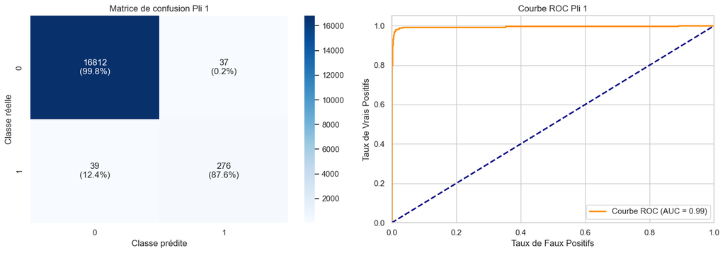

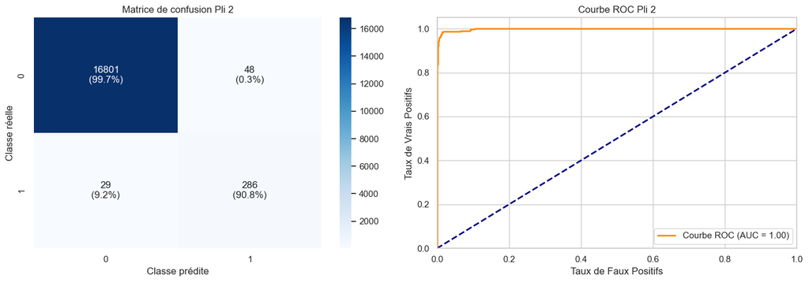

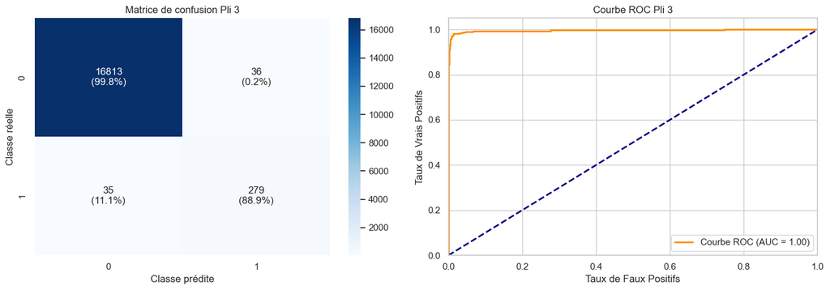

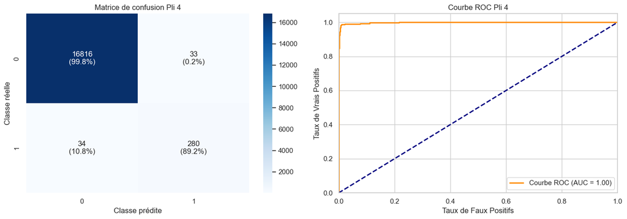

```python
import warnings
from sklearn.metrics import classification_report, f1_score, confusion_matrix, roc_curve, auc
from imblearn.over_sampling import BorderlineSMOTE
from scipy.stats import mode
from sklearn.metrics import roc_auc_score

warnings.filterwarnings('ignore', category=UserWarning, module='lightgbm')

# Validation croisée pour évaluer la performance du modèle

cv_reports = []
f1_scores = []
roc_auc_scores = []
predictions = []
pred_prob = []
base_estimator = DecisionTreeClassifier()

# Boucle sur chaque pli (fold) de la validation croisée
for fold, (train_idx, valid_idx) in enumerate(cv.split(X, y), 1):

    # Sélection des données d'entraînement et de validation pour chaque pli
    X_fold_train = X.iloc[train_idx]
    X_fold_valid = X.iloc[valid_idx]
    y_fold_train = y.iloc[train_idx]
    y_fold_valid = y.iloc[valid_idx]

    # Application de SMOTE pour générer des échantillons synthétiques
    smote = BorderlineSMOTE(sampling_strategy=0.45, random_state=seed)

    # Appliquer SMOTE uniquement sur les données d'entraînement de ce pli
    X_fold_train_smote, y_fold_train_smote = smote.fit_resample(X_fold_train, y_fold_train)

    # Calcul de scale_pos_weight pour compenser le déséquilibre des classes
    scale_pos_weight = len(y_fold_train_smote[y_fold_train_smote == 1]) * 0.75 / len(y_fold_train_smote[y_fold_train_smote == 0])

    # Initialisation des modèles avec les paramètres optimaux et suppression des warnings
    model1 = xgb.XGBClassifier(**xgb_best_params, scale_pos_weight=scale_pos_weight, random_state=seed, verbosity=0)
    model2 = LGBMClassifier(**lgb_best_params, scale_pos_weight=scale_pos_weight, random_state=seed, verbosity=-1)
    model3 = CatBoostClassifier(**cat_best_params, scale_pos_weight=scale_pos_weight, random_state=seed, silent=True)

    # Entraînement des modèles sur le pli avec SMOTE
    model1.fit(X_fold_train_smote, y_fold_train_smote)
    model2.fit(X_fold_train_smote, y_fold_train_smote)
    model3.fit(X_fold_train_smote, y_fold_train_smote)

    # Prédiction sur l'ensemble de validation
    pred_1 = model1.predict(X_fold_valid)
    pred_2 = model2.predict(X_fold_valid)
    pred_3 = model3.predict(X_fold_valid)

    # Combinaison des prédictions via la méthode de mode (majorité des votes)
    predictions = mode([pred_1, pred_2, pred_3], axis=0).mode.flatten()

    # Rapport de classification pour ce pli
    report = classification_report(y_fold_valid, predictions, output_dict=True)
    cv_reports.append(report)

    # Calcul et stockage du score F1 pour ce pli
    f1 = f1_score(predictions, y_fold_valid)
    f1_scores.append(f1)

    # Calcul de la matrice de confusion
    cm = confusion_matrix(y_fold_valid, predictions)

    # Calcul des pourcentages par classe réelle (normalisation par ligne)
    cm_sum = cm.sum(axis=1, keepdims=True)
    cm_perc = (cm / cm_sum.astype(float)) * 100

    # Création d'une matrice d'annotations combinant compte et pourcentage
    labels = np.empty_like(cm, dtype=object)
    for i in range(cm.shape[0]):
        for j in range(cm.shape[1]):
            labels[i, j] = f"{cm[i,j]}\n({cm_perc[i,j]:.1f}%)"

    # Création de la figure pour afficher les graphiques sur la même ligne
    fig, axes = plt.subplots(1, 2, figsize=(14, 5))  # 1 ligne et 2 colonnes pour les graphiques

    # Affichage de la matrice de confusion
    sns.heatmap(cm, annot=labels, fmt="", cmap="Blues", ax=axes[0])
    axes[0].set_xlabel("Classe prédite")
    axes[0].set_ylabel("Classe réelle")
    axes[0].set_title(f"Matrice de confusion Pli {fold}")

    # Courbe ROC
    fpr, tpr, thresholds = roc_curve(y_fold_valid, model2.predict_proba(X_fold_valid)[:, 1])
    roc_auc = auc(fpr, tpr)
    roc_auc_scores.append(roc_auc)

    axes[1].plot(fpr, tpr, color='darkorange', lw=2, label=f'Courbe ROC (AUC = {roc_auc:.2f})')
    axes[1].plot([0, 1], [0, 1], color='navy', lw=2, linestyle='--')
    axes[1].set_xlim([0.0, 1.0])
    axes[1].set_ylim([0.0, 1.05])
    axes[1].set_xlabel('Taux de Faux Positifs')
    axes[1].set_ylabel('Taux de Vrais Positifs')
    axes[1].set_title(f'Courbe ROC Pli {fold}')
    axes[1].legend(loc='lower right')

    # Sauvegarder les graphiques
    plt.tight_layout()
    plt.savefig(f"output/Fold_{fold}_Confusion_ROC.svg", format="svg")
    plt.show()
```

```python
# Résumé des résultats de la validation croisée
print(f"Score F1 moyen sur tous les plis : {np.mean(f1_scores):.4f}")
```

```
Score F1 moyen sur tous les plis : 0.8852
```

### Prédiction sur les données de test à l'aide des modèles

```python
X, y = train_df[features_for_modelling], train_df['target']

predictions = []
pred_prob = []
base_estimator = DecisionTreeClassifier()

# Boucle sur chaque pli (fold) de la validation croisée
for fold, (train_idx, valid_idx) in enumerate(cv.split(X, y), 1):

    # Sélection des données d'entraînement et de validation pour chaque pli
    X_fold_train = X.iloc[train_idx]
    X_fold_valid = X.iloc[valid_idx]
    y_fold_train = y.iloc[train_idx]
    y_fold_valid = y.iloc[valid_idx]

    # Application de SMOTE pour générer des échantillons synthétiques
    smote = BorderlineSMOTE(sampling_strategy=0.45, random_state=seed)

    # Appliquer SMOTE uniquement sur les données d'entraînement de ce pli
    X_fold_train_smote, y_fold_train_smote = smote.fit_resample(X_fold_train, y_fold_train)

    # Calcul de scale_pos_weight pour compenser le déséquilibre des classes
    scale_pos_weight = len(y_fold_train_smote[y_fold_train_smote == 1]) * 0.75 / len(y_fold_train_smote[y_fold_train_smote == 0])

    # Initialisation des modèles avec les paramètres optimaux
    model1 = xgb.XGBClassifier(**xgb_best_params, scale_pos_weight=scale_pos_weight, random_state=seed)
    model2 = LGBMClassifier(**lgb_best_params, scale_pos_weight=scale_pos_weight, random_state=seed)
    model3 = CatBoostClassifier(**cat_best_params, scale_pos_weight=scale_pos_weight, random_state=seed)

    # Entraînement des modèles sur le pli avec SMOTE
    model1.fit(X_fold_train_smote, y_fold_train_smote)
    model2.fit(X_fold_train_smote, y_fold_train_smote)
    model3.fit(X_fold_train_smote, y_fold_train_smote)

    # Prédiction sur l'ensemble de test avec les modèles
    pred_1 = model1.predict(test_df[features_for_modelling])
    pred_2 = model2.predict(test_df[features_for_modelling])
    pred_3 = model3.predict(test_df[features_for_modelling])
    pred_p_1 = model1.predict_proba(test_df[features_for_modelling])
    pred_p_2 = model2.predict_proba(test_df[features_for_modelling])
    pred_p_3 = model3.predict_proba(test_df[features_for_modelling])

    # Ajouter les prédictions
    predictions.append(pred_1)
    predictions.append(pred_2)
    predictions.append(pred_3)
    pred_prob.append(pred_p_1)
    pred_prob.append(pred_p_2)
    pred_prob.append(pred_p_3)
```

[output not shown]

[output cut: 1945 more lines]

[output not shown]

```python
final_predictions = mode(predictions, axis=0).mode.flatten()
final_pred_proba=np.mean(pred_prob,axis=0)
test_df['target'] = final_predictions
test_df[['proba','proba2']]= final_pred_proba
```

## Interprétation des modèles

```python
import joblib

# load models
model1 = joblib.load('Model/model1.pkl')
model2 = joblib.load('Model/model2.pkl')
model3 = joblib.load('Model/model3.pkl')
```

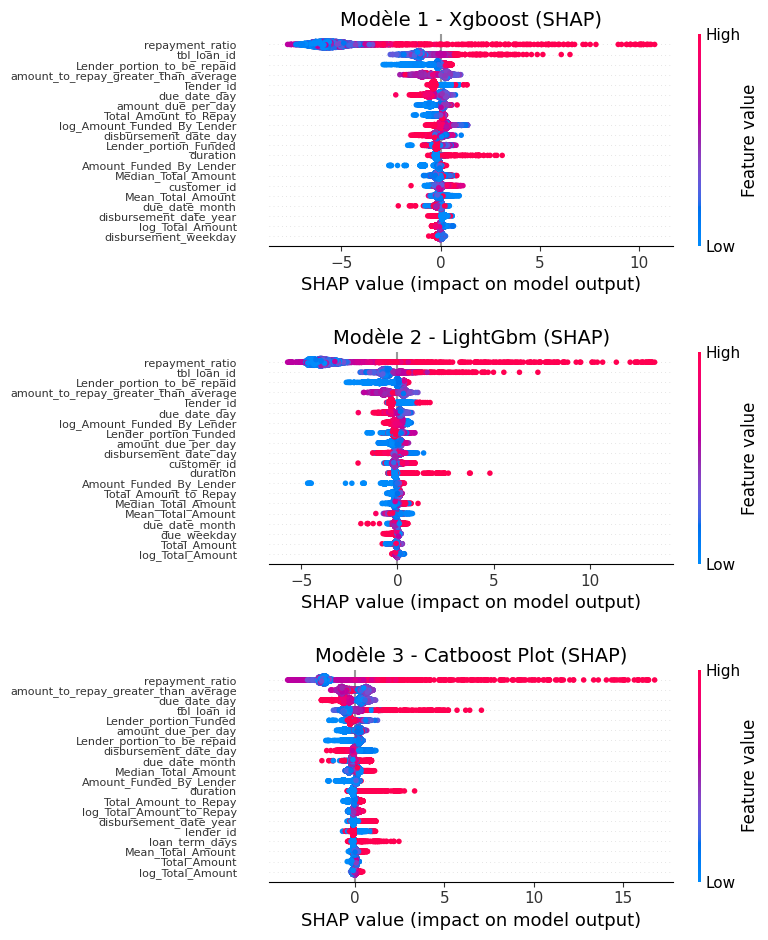

```python
import shap
import matplotlib.pyplot as plt

# Échantillon de données (pour accélérer le calcul)
X_sample = shap.utils.sample(X_train, 5000)

# Fonction pour récupérer les valeurs SHAP pour un modèle
def get_shap_values(model, X):
    explainer = shap.TreeExplainer(model)
    shap_values = explainer.shap_values(X)

    # Si classification binaire avec deux classes, retourner la classe positive
    if isinstance(shap_values, list):
        return shap_values[1]
    return shap_values

# Récupérer les valeurs SHAP pour chaque modèle
shap_values1 = get_shap_values(model1, X_sample)
shap_values2 = get_shap_values(model2, X_sample)
shap_values3 = get_shap_values(model3, X_sample)

# Créer une figure avec 3 subplots (vertical)
fig, axes = plt.subplots(3, 1, figsize=(14, 18))

# Fonction générique pour tracer un beeswarm avec police personnalisée
def plot_shap_with_font(ax, shap_values, title, feature_name_size=10):
    plt.sca(ax)
    shap.summary_plot(shap_values, X_sample, show=False)
    ax.set_title(title, fontsize=14)

    # Réduire la taille de la police des noms des features (axe Y)
    yticklabels = ax.get_yticklabels()
    if yticklabels:
        for label in yticklabels:
            label.set_fontsize(feature_name_size)

# Tracer les trois graphiques
plot_shap_with_font(axes[0], shap_values1, "Modèle 1 - Xgboost (SHAP)", feature_name_size=8)
plot_shap_with_font(axes[1], shap_values2, "Modèle 2 - LightGbm (SHAP)", feature_name_size=8)
plot_shap_with_font(axes[2], shap_values3, "Modèle 3 - Catboost Plot (SHAP)", feature_name_size=8)

# Ajuster l'affichage
plt.tight_layout()
plt.subplots_adjust(hspace=0.5)
plt.show()
```

- Des valeurs élevées (points roses à droite) font fortement basculer la prédiction vers le défaut de paiement.
- Des valeurs basses (points bleus à gauche) indiquent une probabilité plus forte de remboursement.

> amount_to_repay_greater_than_average (différence par rapport à la moyenne) apparaît dans le top 5 de tous les modèles :
- Si le montant à rembourser dépasse largement la moyenne, le risque de défaut augmente nettement.